# Portfolio Selection, by Harry Markowitz

Marco de Pereira Binda

##### Markowitz, Harry. **Portfolio Selection**. The Journal of Finance, vol. 7, no. 1, 1952, pp. 77–91. JSTOR, www.jstor.org/stable/2975974.

### Introdução

Markowitz inicia seu trabalho rejeitando duas hipóteses (ou máximas) de investimentos:

1. que o investidor deve maximizar o valor descontado (ou capitalizado) de retornos futuros:
   1. Ignoradas as imperfeições do mercado, essa regra implica que não poderia haver um portifólio diversificado que seria preferível a todo portifólio não diversificado (e, como será demonstrado, diversificação é fato observado e sensato);
   2. Significa, ainda, que dois ou mais ativos com igual valor descontado seriam idênticos, não importando as taxas de desconto utilizadas ou a variabilidade de seus retornos.
2. que o investidor deve tanto diversificar quanto maximizar o valor descontado (ou capitalizado) de retornos futuros:
   1. A Lei dos Grandes números garante que existe um portifólio que apresente tanto o máximo retorno esperando quanto menor variância;
   2. A afirmação anterior, contudo, não é válida para um portifólio de ativos, pois seus retornos são muito intercorrelacionados, de forma que a diversificação não é capaz de eliminar toda a variância;
   3. O portifólio de maior retorno esperado não é, necessariamente, o de menor variância, podendo o investidor selecionar um portifólio de maior retorno esperado, assumindo mais variância, e reduzir a variância, abrindo mão de parte do retorno esperado.

### Retorno - Risco (E-V)

Makowitz apresenta então sua regra para formação de um portifólio, a do retorno esperado - variância do retorno (E-V).

Seja $R_{i}$ o retorno do ativo $i$ e $X_{i}$ a participação do ativo $i$ no portifólio $R$, o retorno esperado deste é dado por:

$$E(R) = X_{1}E(R_{1}) + X_{2}E(R_{2}) + ... + X_{n}E(R_{n})$$

logo, o retorno esperado do portifólio é a soma dos retornos esperados de cada ativo, ponderados por sua respectiva participação no portifólio. De forma resumida:

$$E(R) = \sum_{i = 1}^{n} X_{i}E(R_{i})$$

### Tabela

```
  # A tibble: 8 x 3
    ativo   risk return
    <chr>  <dbl>  <dbl>
  1 BVSP   0.217  0.285
  2 BOVA11 0.222  0.288
  3 SMAL11 0.209  0.357
  4 VALE3  0.466  0.444
  5 ITUB4  0.291  0.243
  6 B3SA3  0.326  0.421
  7 PETR4  0.473  0.471
  8 BBDC4  0.345  0.357
```

### Gráfico

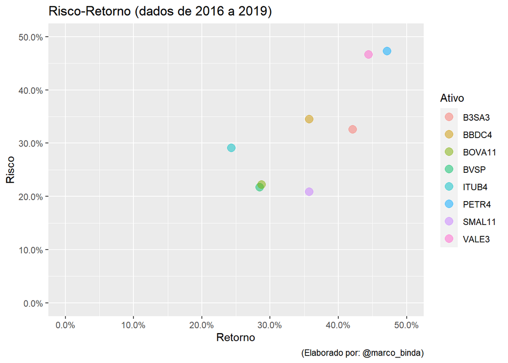